# CEU Data Analysis 4

Assignment 1

Cagdas Yetkin

2018-02-11

[figure not shown]

London, city of Sherlock, Harry Potter, Dorian Gray and many others…

Our client is a mid size real estate company trying to enter into airbnb business in London. Their new revenue model is to build or purchase flats and houses, renovate them and then list on the website. They also want to expand the business to Budapest Hungary soon.

Our task is to help them on the pricing issue by using the historical data publicly available online.

```r
library(doParallel)
library(ggplot2)
library(data.table)
library(caret)
library(glmnet)
library(dplyr)
library(ggthemes) #fivethirtyeight plots
library(skimr) #magical summaries
library(gridExtra) #combine plots
library(stargazer) #checked a few coeffs
library(knitr)
library(kableExtra) #html formating

registerDoParallel(cores = 4)
knitr::opts_chunk$set(warning = FALSE)
```

We need to get rid of some dublicates

```r
data <- fread("airbnb_london_workfile.csv", stringsAsFactors = TRUE)

data[, c("neighbourhood_cleansed", "cancellation_policy",
         "usd_price_day", "property_type", "room_type")  := NULL]

data[, neighbourhood_cleansed := NULL]

names(data)
```

```
##  [1] "usd_cleaning_fee"          "f_property_type"
##  [3] "f_room_type"               "f_cancellation_policy"
##  [5] "f_bed_type"                "f_neighbourhood_cleansed"
##  [7] "p_host_response_rate"      "n_accommodates"
##  [9] "n_bathrooms"               "n_review_scores_rating"
## [11] "n_number_of_reviews"       "n_guests_included"
## [13] "n_reviews_per_month"       "n_extra_people"
## [15] "n_minimum_nights"          "n_beds"
## [17] "n_days_since"              "d_24hourcheckin"
## [19] "d_airconditioning"         "d_breakfast"
## [21] "d_buzzerwirelessintercom"  "d_cabletv"
## [23] "d_carbonmonoxidedetector"  "d_cats"
## [25] "d_dogs"                    "d_doorman"
## [27] "d_doormanentry"            "d_dryer"
## [29] "d_elevatorinbuilding"      "d_essentials"
```

[output cut: 19 more lines]

```r
data[, price := as.numeric(price)]
```

Since these properties will be renovated new listings they will not have any review or review related scores. Later on we can build a new model for the existing ones. However, we will drop them for this initial study.

Cleaning of the properties will be a standardized process. In the data when the cleaning fee is missing it is actually zero. And sometimes this feature is misused by the oweners. We will not use this feature as well.

```r
data[, c("n_review_scores_rating", "n_reviews_per_month",
         "n_number_of_reviews", "n_days_since", "p_host_response_rate", "usd_cleaning_fee")  := NULL]
```

Do we have missing variables?

```r
sapply(data, function(x) sum(is.na(x)))
```

```
##           f_property_type               f_room_type
##                         0                         0
##     f_cancellation_policy                f_bed_type
##                         0                         0
##  f_neighbourhood_cleansed            n_accommodates
##                         0                         0
##               n_bathrooms         n_guests_included
##                       237                         0
##            n_extra_people          n_minimum_nights
##                         0                         0
##                    n_beds           d_24hourcheckin
##                       167                         0
##         d_airconditioning               d_breakfast
##                         0                         0
##  d_buzzerwirelessintercom                 d_cabletv
##                         0                         0
##  d_carbonmonoxidedetector                    d_cats
##                         0                         0
##                    d_dogs                 d_doorman
##                         0                         0
##            d_doormanentry                   d_dryer
##                         0                         0
##      d_elevatorinbuilding              d_essentials
##                         0                         0
##       d_familykidfriendly        d_fireextinguisher
##                         0                         0
##             d_firstaidkit   d_freeparkingonpremises
##                         0                         0
##     d_freeparkingonstreet                     d_gym
##                         0                         0
##               d_hairdryer                 d_hangers
##                         0                         0
##                 d_heating                  d_hottub
##                         0                         0
##         d_indoorfireplace                d_internet
##                         0                         0
##                    d_iron                  d_keypad
##                         0                         0
##                 d_kitchen d_laptopfriendlyworkspace
##                         0                         0
##       d_lockonbedroomdoor                 d_lockbox
##                         0                         0
##               d_otherpets  d_paidparkingoffpremises
##                         0                         0
##             d_petsallowed  d_petsliveonthisproperty
##                         0                         0
##                    d_pool         d_privateentrance
##                         0                         0
##       d_privatelivingroom              d_safetycard
##                         0                         0
##             d_selfcheckin                 d_shampoo
##                         0                         0
##               d_smartlock           d_smokedetector
##                         0                         0
##          d_smokingallowed       d_suitableforevents
##                         0                         0
##                      d_tv                  d_washer
##                         0                         0
##             d_washerdryer    d_wheelchairaccessible
##                         0                         0
##        d_wirelessinternet                     price
##                         0                         0
```

n_bathrooms (237), n_beds (167) have missing values.

We will use median value for the bathrooms assuming that 1 bathroom should be available. Number of beds should be equal to the number of accommodate for the missing ones.

```r
data[, n_bathrooms :=
       ifelse(is.na(n_bathrooms), median(n_bathrooms, na.rm = T), n_bathrooms)]

data[, n_beds :=
       ifelse(is.na(n_beds), n_accommodates, n_beds)]

#a few observations with strange prices. Illogical and outscope numbers create noise to our business question.
data <- data[data$price > 10, ]
data <- data[data$price < 700, ]
```

```r
#Below is the small gadget i wrote to study my variables in detail.
sapply(data, function(x) if (class(x) == 'factor') {unique(x)
  } else if (class(x) != 'factor') {skim(x)})
```

```r
#take another look
glimpse(data)
```

How is the average price changing district by district?

```r
data[, .(count = .N,
         avg_price = round(mean(price)),
         median_price = round(median(price)),
         min = min(price),
         max = max(price)),
                 by = f_neighbourhood_cleansed][order(-avg_price)] %>%
  filter(count > 1000)
```

| f_neighbourhood_cleansed | count | avg_price | median_price | min | max |
| --- | --- | --- | --- | --- | --- |
| Kensington and Chelsea | 3327 | 145 | 120 | 20 | 695 |
| Westminster | 5202 | 137 | 110 | 19 | 691 |
| Camden | 3623 | 112 | 95 | 15 | 666 |
| Hammersmith and Fulham | 2689 | 104 | 82 | 11 | 699 |
| Wandsworth | 2602 | 96 | 75 | 15 | 650 |
| Islington | 3478 | 94 | 80 | 11 | 654 |
| Southwark | 3241 | 86 | 69 | 11 | 699 |
| Lambeth | 3176 | 84 | 65 | 15 | 682 |
| Brent | 1537 | 81 | 60 | 15 | 669 |
| Hackney | 4492 | 80 | 65 | 11 | 500 |

[output cut: 4 more lines]

Now time to select a random district…

```r
#a dplyr way...
set.seed(22) #reproduce
selection_table <- data %>%
                      group_by(f_neighbourhood_cleansed) %>%
                      tally() %>%
                      filter(n > 1000) %>%
                      arrange(desc(n))


lottery_winner <- as.vector(sample(selection_table$f_neighbourhood_cleansed, 1))
lottery_winner
```

```
## [1] "Islington"
```

Hello My District… This is the area where **Sherlock Holmes** lived.

```r
district <- data %>%
              filter(f_neighbourhood_cleansed == lottery_winner)
```

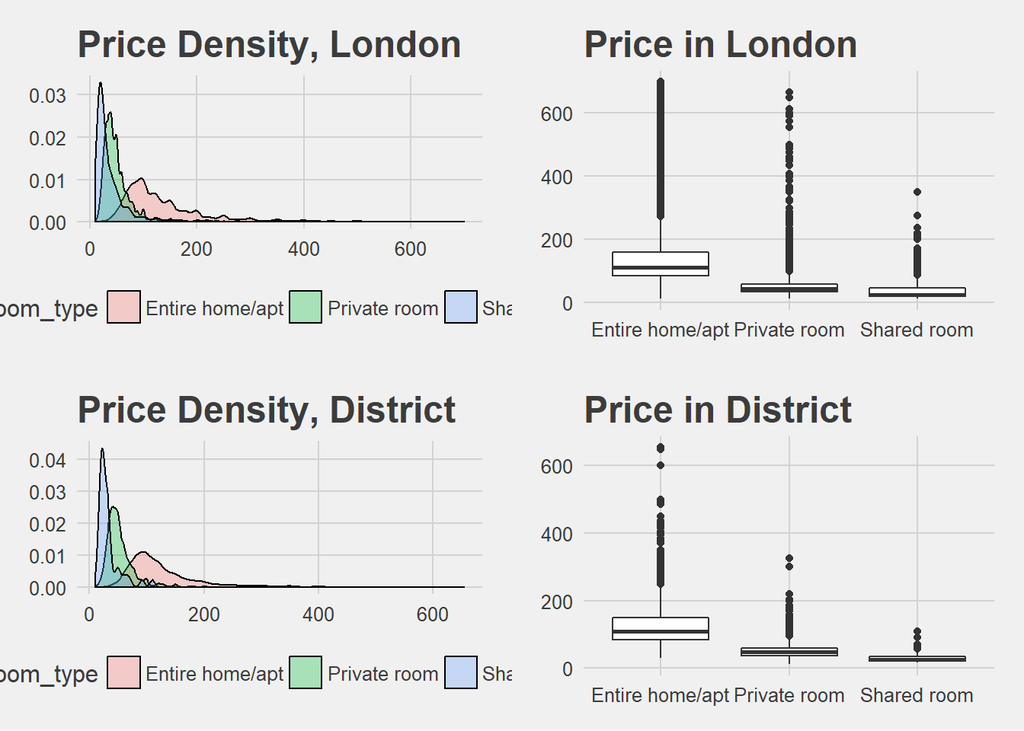

```r
## Distribution of price by type
plot1 <- ggplot(data, aes(price, fill = f_room_type)) +
         ggtitle("Price Density, London") +
         geom_density(alpha = 0.3) + theme_fivethirtyeight()

## Boxplot of price by room type
plot2 <- ggplot(data, aes(f_room_type, price)) +
         ggtitle("Price in London") +
         geom_boxplot()+ theme_fivethirtyeight()

plot3 <- ggplot(district, aes(price, fill = f_room_type)) +
         ggtitle("Price Density, District") +
         geom_density(alpha = 0.3) + theme_fivethirtyeight()

## Boxplot of price by room type
plot4 <- ggplot(district, aes(f_room_type, price)) +
         ggtitle("Price in District") +
         geom_boxplot()+ theme_fivethirtyeight()

grid.arrange(plot1, plot2, plot3, plot4, ncol=2, nrow=2)
```

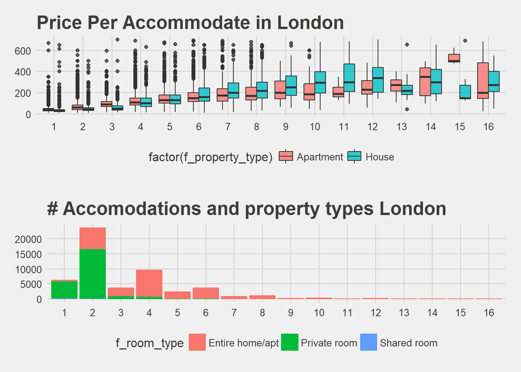

```r
plot5 <- ggplot(data, aes(x = factor(n_accommodates), y = price, fill = factor(f_property_type))) +
         geom_boxplot(alpha=0.8) +
         scale_x_discrete(name = "Accomodate Persons") +
         ggtitle("Price Per Accommodate in London") + theme_fivethirtyeight()

plot6 <- ggplot(data = data) +
         geom_bar(data = data,
         aes(x = factor(n_accommodates),
         color = f_room_type, fill = f_room_type)) +
         ggtitle("# Accomodations and property types London") +
         xlab('Accommodates') + theme_fivethirtyeight()

grid.arrange(plot5, plot6, nrow=2)
```

Accommodate is an important feature we will need to pay attention.

There is a wide range of price. So there must be some factors which make differences. Now I will leave the path and enter into a random forest to see which variables it picks.

This will be a heuristic approach. Because I am lacking the domain knowledge in this business, I will use random forest to pick the most important (highly likely) variables for me. It is probabilistic, however, it can be a better start than knowing nothing at all.

```r
# Fit random forest
RFtrainControl <- trainControl(method = "cv",
                               number = 2,
                               verboseIter = TRUE)
set.seed(1234)
RFmodel <- train(
  price ~ .,
  tuneLength = 1,
  data = district,
  method = 'ranger',
  na.action = na.omit,
  importance = 'impurity',
  trControl = RFtrainControl)
varImp(RFmodel)
```

```
## ranger variable importance
##
##   only 20 most important variables shown (out of 94)
##
##                             Overall
## n_accommodates              100.000
## f_room_typePrivate room      68.106
## n_beds                       63.804
## n_bathrooms                  47.317
## n_guests_included            24.744
## f_property_typeHouse         16.489
## n_minimum_nights             15.975
## d_tv                         13.948
## f_cancellation_policystrict  13.741
## n_extra_people               13.692
## d_familykidfriendly          12.316
## d_laptopfriendlyworkspace     5.564
## d_cabletv                     5.243
## d_dryer                       5.018
## d_elevatorinbuilding          4.859
## d_indoorfireplace             4.723
## d_buzzerwirelessintercom      4.602
## d_carbonmonoxidedetector      4.592
## d_shampoo                     4.329
## d_iron                        4.285
```

Accommodates looks like the most important variable indeed. And for example being kid friendly might have some effect. Below we can see its plot, error bars added to emphasise the level of uncertainty.

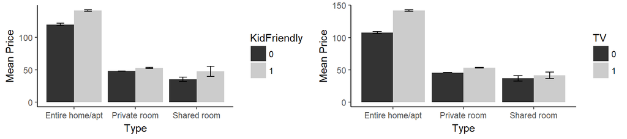

```r
library(psych)

stats <- describeBy(data$price,list(data$f_room_type,data$d_familykidfriendly), mat=TRUE,digits=2)
stats$se = stats$sd/sqrt(stats$n)
names(stats)[names(stats) == 'group1'] = 'Type'
names(stats)[names(stats) == 'group2'] = 'KidFriendly'

stats_2 <- describeBy(data$price,list(data$f_room_type,data$d_tv), mat=TRUE,digits=2)
stats_2$se = stats_2$sd/sqrt(stats_2$n)
names(stats_2)[names(stats_2) == 'group1'] = 'Type'
names(stats_2)[names(stats_2) == 'group2'] = 'TV'


limits = aes(ymax = mean + (1.96*se), ymin=mean - (1.96*se))
dodge = position_dodge(width=0.9)

apatheme=theme_bw()+
  theme(panel.grid.major=element_blank(),
        panel.grid.minor=element_blank(),
        panel.border=element_blank(),
        axis.line=element_line())

p7 <- ggplot(stats, aes(x = Type, y = mean, fill = KidFriendly))+
  geom_bar(stat='identity', position=dodge)+
  geom_errorbar(limits, position=dodge, width=0.25)+
  ylab('Mean Price')+
  theme_fivethirtyeight() + apatheme +
  scale_fill_grey()

p8<- ggplot(stats_2, aes(x = Type, y = mean, fill = TV))+
  geom_bar(stat='identity', position=dodge)+
  geom_errorbar(limits, position=dodge, width=0.25)+
  ylab('Mean Price')+
  theme_fivethirtyeight() + apatheme +
  scale_fill_grey()

grid.arrange(p7, p8, ncol=2)
```

Playing our card to be-kid-friendly, we can increase our profits. Maybe the families with small kids are ready to pay more than young couples and singles. We will try these interactions during modeling.

```r
london <- data[complete.cases(data)]
district <- data.table(district)
district <- district[complete.cases(district)]
```

partitioning to training and test sets

```r
training_ratio <- 0.7

set.seed(1234)
train_indices <- createDataPartition(y = london[["price"]],
                                     times = 1,
                                     p = training_ratio,
                                     list = FALSE)
london_train <- london[train_indices, ]
london_test <- london[-train_indices, ]
```

```r
set.seed(1234)
train_indices <- createDataPartition(y = district[["price"]],
                                     times = 1,
                                     p = training_ratio,
                                     list = FALSE)

district_train <- district[train_indices, ]
district_test <- district[-train_indices, ]
```

```r
fit_control <- trainControl(method = "cv", number = 10)
```

### 1) Linear 1

```r
set.seed(1234) # The most simple one for benchmarking or comparing...
model_1_london <- train(price ~ n_accommodates,
                   data = london_train,
                   method = "lm",
                   trControl = fit_control)
```

```r
set.seed(1234)
model_1_district <- train(price ~ n_accommodates,
                   data = district_train,
                   method = "lm",
                   trControl = fit_control)
```

### 2) Linear 2

```r
set.seed(1234) # Adding some more variables from our exploration to see the effects
model_2_london <- train(price ~ n_accommodates + n_beds + f_room_type +
                         n_minimum_nights + n_guests_included + n_bathrooms,
                   data = london_train,
                   method = "lm",
                   trControl = fit_control)
```

```r
set.seed(1234) #
model_2_district <- train(price ~ n_accommodates + n_beds + f_room_type +
                         n_minimum_nights + n_guests_included + n_bathrooms,
                   data = district_train,
                   method = "lm",
                   trControl = fit_control)
```

### 3) Linear 3

```r
set.seed(1234) # load the variables from random forest varible importance list and some interactions and polynomials
model_3_london <- train(price ~ n_accommodates + n_beds + f_room_type + n_bathrooms + n_guests_included +
                          n_minimum_nights + f_property_type + n_extra_people + f_cancellation_policy +
                          d_tv + d_familykidfriendly + d_cabletv + d_laptopfriendlyworkspace + d_dryer +
                          d_elevatorinbuilding + d_indoorfireplace  + d_buzzerwirelessintercom
                          + d_carbonmonoxidedetector + d_hangers + d_internet +
                          n_accommodates^2 + n_beds^2 + f_property_type*d_familykidfriendly +
                          n_accommodates*d_tv + n_accommodates*d_familykidfriendly + n_accommodates*d_cabletv,
                   data = london_train,
                   method = "lm",
                   trControl = fit_control)
```

```r
set.seed(1234) #load the variables from random forest varible importance list and some interactions and polynomials
model_3_district <- train(price ~ n_accommodates + n_beds + f_room_type + n_bathrooms + n_guests_included +
                          n_minimum_nights + f_property_type + n_extra_people + f_cancellation_policy +
                          d_tv + d_familykidfriendly + d_cabletv + d_laptopfriendlyworkspace + d_dryer +
                          d_elevatorinbuilding + d_indoorfireplace  + d_buzzerwirelessintercom
                          + d_carbonmonoxidedetector + d_hangers + d_internet +
                          n_accommodates^2 + n_beds^2 + f_property_type*d_familykidfriendly +
                          n_accommodates*d_tv + n_accommodates*d_familykidfriendly + n_accommodates*d_cabletv,
                   data = district_train,
                   method = "lm",
                   trControl = fit_control)
```

### 4) LASSO with super low lambdas, targeting lower RMSE score here:

```r
tune_grid <- expand.grid("alpha" = 1,
                         "lambda" = seq(0.028, 0.036, 0.001))

set.seed(1234) # lasso.
model_4_london <- train(price ~ .,
                   data = london_train,
                   method = "glmnet",
                   trControl = fit_control,
                   metric = "RMSE",
                   preProcess = c("center","scale"),
                   tuneGrid = tune_grid,
                   tuneLength=3)
```

```r
tune_grid <- expand.grid("alpha" = 1,
                         "lambda" = seq(0.25, 0.35, 0.01))

set.seed(1234) # lasso
model_4_district <- train(price ~ .,
                   data = district_train,
                   method = "glmnet",
                   trControl = fit_control,
                   metric = "RMSE",
                   tuneGrid = tune_grid)
```

Cross Validation RMSEs

```r
model_1_london_rmse_cv <- model_1_london$results[["RMSE"]]
model_2_london_rmse_cv <- model_2_london$results[["RMSE"]]
model_3_london_rmse_cv <- model_3_london$results[["RMSE"]]
model_4_london_rmse_cv <- min(model_4_london$results[["RMSE"]])

model_1_district_rmse_cv <- model_1_district$results[["RMSE"]]
model_2_district_rmse_cv <- model_2_district$results[["RMSE"]]
model_3_district_rmse_cv <- model_3_district$results[["RMSE"]]
model_4_district_rmse_cv <- min(model_4_district$results[["RMSE"]])
```

How do these models behave on test sets and the full sample? I have run all the predictions and listed them in a table below.

A table of RMSE results

| model | London.CV | London.FULL | London.Test | District.CV | District.FULL | District.Test |
| --- | --- | --- | --- | --- | --- | --- |
| 1 | 56.88620 | 56.86150 | 56.76752 | 44.85741 | 56.88700 | 44.87183 |
| 2 | 51.87963 | 51.91287 | 52.00512 | 43.33008 | 52.51055 | 41.26231 |
| 3 | 50.71307 | 50.70093 | 50.80065 | 41.30163 | 52.42717 | 41.37934 |
| 4 | 47.96992 | 47.90514 | 48.09877 | 40.97675 | 52.00675 | 40.45492 |

lasso (number 4) is giving better RMSE results on test set, for both London and the district. I would use Lasso for both of them.

District is a representative sample of London. Price is distributed very similarly. However, when we try the model of the district to predict the entire London, we do a poor job. District is a small sample and its model cant capture the variation for the entire city.

Cross Validation and Test Set RMSE scores are almost identical. It is logical since the process of CV is to create several test sets and they are coming from the same data using random sampling.

We would use these models also for predicting 2018 prices for London. Because we think that 2018 will be similar to 2017. On the other hand Budapest prices are very different. I wouldn’t predict the price by using a model from London. It will overshoot first of all… Having said that, I can use the experience I gained from London to build new models for other cities. Especially during the process of picking the right coefficients or variables.

In my second iteration I would also use one of the variables I dropped at the beginning which are related to reviews. Probably reviews and review scores would have some effect if engineered carefully. Reviews, review scores are more touching to behavioural science and tend to contain more noise.

I would also be curious about how rating scores changes over time.

### CART and Random Forest Results

Now we can grow a tree and see its results.

```r
trctrl <- trainControl(method = "cv", number = 10)

set.seed(1234)
model_tree1_london <- train(price ~ .,

                     data = london_train, method = "rpart",
                     metric = "RMSE",
                     trControl=trctrl,
                     tuneLength = 20,
                     tuneGrid = data.frame(cp=seq(0.001, 0.01, 0.01))) #0.00001, 0.001, 0.0001
model_tree1_london
```

```
## CART
##
## 36090 samples
##    61 predictor
##
## No pre-processing
## Resampling: Cross-Validated (10 fold)
## Summary of sample sizes: 32481, 32481, 32481, 32481, 32480, 32482, ...
## Resampling results:
##
##   RMSE      Rsquared   MAE
##   48.24238  0.5944131  29.1418
##
## Tuning parameter 'cp' was held constant at a value of 0.001
```

```r
postResample(london_test$price, predict(model_tree1_london, newdata = london_test, type = "raw"))
```

```
##       RMSE   Rsquared        MAE
## 48.7178292  0.5904734 29.4880805
```

A regression tree is giving quite promising results for the london test set. RMSE is already as good as the Lasso.

Lets get the result also for our district:

```r
trctrl <- trainControl(method = "cv", number = 10)

set.seed(1234)
model_tree1_district <- train(price ~ .,

                     data = district_train, method = "rpart",
                     metric = "RMSE",
                     trControl=trctrl,
                     tuneLength = 20,
                     tuneGrid = data.frame(cp=seq(0.003, 0.0036, 0.0001)))
model_tree1_district
```

```
## CART
##
## 2436 samples
##   61 predictor
##
## No pre-processing
## Resampling: Cross-Validated (10 fold)
## Summary of sample sizes: 2193, 2193, 2192, 2192, 2194, 2191, ...
## Resampling results across tuning parameters:
##
##   cp      RMSE      Rsquared   MAE
##   0.0030  39.65540  0.6178117  25.71466
##   0.0031  39.65540  0.6178117  25.71466
##   0.0032  39.64336  0.6180021  25.75005
##   0.0033  39.64210  0.6180115  25.74834
##   0.0034  39.64587  0.6178014  25.79159
##   0.0035  39.64611  0.6176206  25.79206
##   0.0036  39.75832  0.6160279  25.86119
##
## RMSE was used to select the optimal model using the smallest value.
## The final value used for the model was cp = 0.0033.
```

Here we can see RMSE change vs complexity parameter of the tree

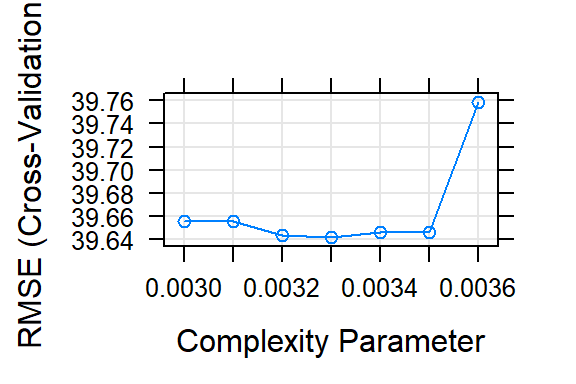

```r
plot(model_tree1_district)
```

```r
postResample(district_test$price, predict(model_tree1_district, newdata = district_test, type = "raw"))
```

```
##       RMSE   Rsquared        MAE
## 41.1274597  0.6239557 25.4295441
```

Again the tree is doing almost as good as lasso.

```r
# Fit random forest to district
RFtrainControl <- trainControl(method = "cv",
                               number = 2,
                               verboseIter = TRUE)
set.seed(1234)
model_RF_district <- train(
  price ~ .,
  tuneLength = 1,
  data = district_train,
  method = 'ranger',
  na.action = na.omit,
  importance = 'impurity',
  trControl = RFtrainControl)
RFmodel
```

```
## Random Forest
##
## 3478 samples
##   61 predictor
##
## No pre-processing
## Resampling: Cross-Validated (2 fold)
## Summary of sample sizes: 1739, 1739
## Resampling results across tuning parameters:
##
##   splitrule   RMSE      Rsquared   MAE
##   variance    38.78331  0.6647095  24.45589
##   extratrees  39.31677  0.6621379  24.93305
##
## Tuning parameter 'mtry' was held constant at a value of 9
## Tuning
##  parameter 'min.node.size' was held constant at a value of 5
## RMSE was used to select the optimal model using the smallest value.
## The final values used for the model were mtry = 9, splitrule =
##  variance and min.node.size = 5.
```

```r
postResample(district_test$price, predict(model_RF_district, newdata = district_test, type = "raw"))
```

```
##       RMSE   Rsquared        MAE
## 38.3658077  0.6890767 24.1235225
```

This Random Forest RMSE is the best so far. It is giving better results than the others. However, it is difficult to explain it to our business stakeholders.

We can plot the trees and explain the linear regression coeffs more effectively to the people. RF model wont enjoy that much clarity. That’s because I would prefer to tweak and play with my linear models and lasso with an objective to get closer to the Random Forest.

Later on I can try the same coeffs to Budapest. I would use the model we built for entire London to work on Budapest. The model we used for the district is less likely to be generalized.

I would like to close this small paper with the plot below showing Lasso Model predictions to show the errors. Predictions are getting worse and worse as the real rental price increases: Predicting less than it is. Similar trend is visible for the predictions of other models as well.

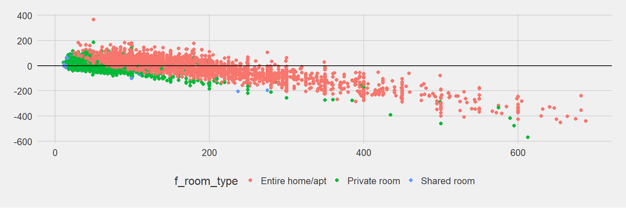

```r
ggplot(london_test, aes(price, model_4_london_pred_test - price, col = f_room_type)) + geom_point() +
  geom_abline(intercept = 0, slope = 0) + theme_fivethirtyeight()
```